# Predictive Regressions in Finance

This notebook takes up one of the most studied (and most argued-over) questions in empirical finance: *can we predict stock returns?* More precisely, does the expected return on the stock market move around over time in a way that we can detect with variables observable today? The main tool is the **predictive regression**, which is just an OLS regression in which the explanatory variable is measured one period *before* the outcome.

The notebook pulls together several earlier threads. It uses OLS regression as developed in `CAPM_BivariateRegression.ipynb` and `MultifactorModels_MultiVarRegression.ipynb`; it relies on the time series ideas in `TimeSeries.ipynb` (autocorrelation, persistence, unit roots, and forecasts as conditional expectations); and it returns to the equity premium from `Equity_Premium_Inference.ipynb`, which treated the expected market excess return as a single constant. Here we ask whether that constant is really moving over time. The data come from the same source as in `Equity_Premium_Inference.ipynb`: Amit Goyal's updated version of the Goyal and Welch (2008) dataset of stock market predictors.

*Acknowledgment*: This notebook was produced with the assistance of AI. I remain responsible for the content and any errors.

## Learning Objectives

By the end of this notebook, you should be able to:

1. Define a predictive regression, and explain why the timing of the predictor relative to the outcome is what makes it "predictive" (and why using information not yet available is cheating).
2. Interpret a return-forecasting regression as a model of the conditional expected return, and explain why a genuinely useful predictor can still produce a small $R^2$.
3. Explain the market-efficiency argument for why returns should be hard to predict, and two alternative views (limits to arbitrage, and rational time variation in risk premiums) under which some predictability is possible.
4. Explain, using the present-value relation, why a valuation ratio such as the dividend-price ratio must forecast future returns, future dividend growth, or both.
5. Estimate predictive regressions in Python with `statsmodels`, lining up predictors and outcomes correctly, and interpret the slope, its $t$-statistic, the $R^2$, and the economic magnitude of the implied variation in expected returns.
6. Explain why a highly persistent predictor biases the OLS slope estimate and makes $t$-tests reject too often, and verify this by simulation.
7. Explain overfitting in multivariate predictive regressions, and what adjusted $R^2$ does (and does not) correct for.
8. Conduct an out-of-sample evaluation with an expanding estimation window, compute the mean squared forecast error and the out-of-sample $R^2$, and interpret a Goyal-Welch cumulative squared-error plot.
9. (Optional, appendix) Derive the log-linear present-value relation for the dividend-price ratio, and write the multivariate predictive regression in vector notation.

## Instructions to Run

**Data:** This notebook uses annual data from Amit Goyal's updated version of the Goyal and Welch (2008, *Review of Financial Studies*, "A Comprehensive Look at the Empirical Performance of Equity Premium Prediction") dataset. A small extract, covering 1926 through 2024 and limited to the columns used here, is already in this repo's `data/` folder as `data/gw_annual.csv`. It comes from the "Annual" sheet of Goyal's `GWPredictorData2024.xlsx` file, with Goyal's column names unchanged (except that `yyyy` is renamed `year`). (Where a notebook instead uses data that can't be redistributed here -- e.g. licensed WRDS data, or simply a larger extract -- the required file(s) will be posted on the course Canvas site under Data instead. Download those into your local `data/` folder before running.)

**If your data lives somewhere else:** Edit the `pd.read_csv("../data/gw_annual.csv")` line in the first code cell (the path assumes this notebook lives in `notebooks/` and `data/` is a sibling folder).

**Package dependencies:** `numpy`, `pandas`, `matplotlib`, and `statsmodels` -- standard scientific-Python packages included in a typical Anaconda install. Otherwise: `pip install numpy pandas matplotlib statsmodels`.

**Viewing the HTML export in Canvas:** If the equations below show up as raw text (things like `$R_{t+1}$`) instead of typeset math, don't use Canvas's built-in file preview -- download the file and open it directly in your browser instead. Canvas's preview sandboxes uploaded HTML and blocks the script that typesets the math; opening the downloaded file locally has no such restriction.

## Motivating Example: Is the Market Expensive?

At the end of 2024, the S&P 500's **dividend-price ratio** (D/P) -- total dividends paid over the year divided by the index level -- stood at about 1.3%. That is close to the lowest value in nearly a century of data. The only comparable readings came in 2021 and around the peak of the dot-com boom, when D/P hit its record low of 1.1% in 1999 -- and the five years that followed 1999 were poor ones for stock investors. At the other extreme, D/P was very high in the depths of the Great Depression and again around 1950 -- times when stocks were cheap relative to the dividends they paid -- and both were followed by years of strong returns.

So, is a low D/P a warning sign? Many market commentators think so. The code below loads the data (the variables are described in more detail later) and plots the D/P ratio over time.

```python
import numpy as np
import pandas as pd
import matplotlib.pyplot as plt
import statsmodels.api as sm
from statsmodels.tsa.ar_model import AutoReg
from statsmodels.tsa.stattools import adfuller

#Annual Goyal-Welch data, 1926-2024 (see Instructions to Run). Column names follow Goyal's file
gw = pd.read_csv("../data/gw_annual.csv")
gw.index = pd.PeriodIndex(gw['year'], freq='Y')

data = pd.DataFrame(index=gw.index)

#Valuation ratios. Lower-case names are logs; the "level" versions are in percent
data['dp'] = np.log(gw['d12']) - np.log(gw['price'])           #log dividend-price ratio
data['dy'] = np.log(gw['d12']) - np.log(gw['price'].shift(1))  #log dividend yield (dividends over last year's price)
data['ep'] = np.log(gw['e12']) - np.log(gw['price'])           #log earnings-price ratio
data['de'] = np.log(gw['d12']) - np.log(gw['e12'])             #log dividend payout ratio (dividends over earnings)
data['bm'] = gw['b/m']                                         #book-to-market ratio (Dow Jones Industrial Average)
data['DPlevel'] = 100 * gw['d12'] / gw['price']                #D/P ratio, in percent
data['EPlevel'] = 100 * gw['e12'] / gw['price']                #E/P ratio, in percent

#Interest rates, yield spreads, and bond returns, all in percent
data['tbl'] = 100 * gw['tbl']                    #3-month Treasury bill yield
data['lty'] = 100 * gw['lty']                    #long-term government bond yield
data['ltr'] = 100 * gw['ltr']                    #long-term government bond return
data['corpr'] = 100 * gw['corpr']                #long-term corporate bond return
data['tms'] = 100 * (gw['lty'] - gw['tbl'])      #term spread
data['dfy'] = 100 * (gw['BAA'] - gw['AAA'])      #default yield spread
data['dfr'] = 100 * (gw['corpr'] - gw['ltr'])    #default return spread

#Other predictors
data['infl'] = 100 * gw['infl']                  #CPI inflation, in percent
data['ntis'] = 100 * gw['ntis']                  #net equity issuance relative to market value, in percent
data['svar'] = gw['svar']                        #stock variance: sum of squared daily S&P 500 returns over the year

#S&P 500 returns including dividends, in percent, and excess returns over the T-bill
data['ret'] = 100 * ((gw['price'] + gw['d12']) / gw['price'].shift(1) - 1)
data['logret'] = 100 * (np.log(gw['price'] + gw['d12']) - np.log(gw['price'].shift(1)))
data['exret'] = data['ret'] - 100 * gw['Rfree']
data['lexret'] = data['logret'] - 100 * np.log(1 + gw['Rfree'])

#1926 is needed only for the lagged price in the 1927 return, so the sample starts in 1927
data = data.loc['1927':]
print(f"Sample: {data.index[0]} to {data.index[-1]}, T = {len(data)} years")
data[['DPlevel', 'exret', 'lexret']].tail()
```

```
Sample: 1927 to 2024, T = 98 years
```

| year | DPlevel | exret | lexret |
| --- | --- | --- | --- |
| 2020 | 1.551591 | 17.537185 | 16.080414 |
| 2021 | 1.267202 | 28.450715 | 25.026439 |
| 2022 | 1.743009 | -19.323084 | -21.168507 |
| 2023 | 1.473924 | 21.117679 | 18.334461 |
| 2024 | 1.272305 | 19.625540 | 17.097568 |

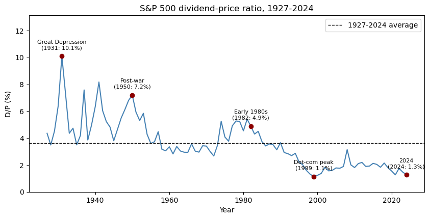

```python
#D/P ratio over time, with a few notable years labeled
years = data.index.year
fig, ax = plt.subplots(figsize=(10, 4.5))
ax.plot(years, data['DPlevel'], color='steelblue', linewidth=1.5)
ax.axhline(data['DPlevel'].mean(), color='black', linestyle='--', linewidth=1, label='1927-2024 average')
for yr, note in [(1931, 'Great Depression'), (1950, 'Post-war'), (1982, 'Early 1980s'),
                 (1999, 'Dot-com peak'), (2024, '2024')]:
    val = data['DPlevel'].loc[str(yr)]
    ax.plot(yr, val, marker='o', color='darkred')
    ax.annotate(f"{note}\n({yr}: {val:.1f}%)", (yr, val), textcoords='offset points', xytext=(0, 8),
                ha='center', va='bottom', fontsize=8)
ax.set_title("S&P 500 dividend-price ratio, 1927-2024")
ax.set_xlabel("Year")
ax.set_ylabel("D/P (%)")
ax.set_ylim(0, data['DPlevel'].max() * 1.3)
ax.legend(loc='upper right')
plt.show()
```

A natural first check: sort the years by their D/P ratio into four equal-sized groups (quartiles), and look at the average excess return in the *following* year for each group. If low D/P really is a warning sign, the low-D/P years should be followed by lower returns on average.

```
                 mean  count
DP quartile
1 (lowest D/P)    6.7     25
2                 6.9     24
3                 4.7     24
4 (highest D/P)  15.4     24
```

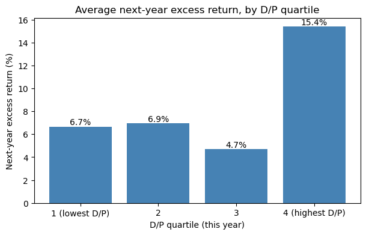

```python
#Line up each year's D/P ratio with the NEXT year's excess return (shift(-1) pulls next year's value back one row)
hook = pd.DataFrame({'DP': data['DPlevel'], 'next_exret': data['exret'].shift(-1)}).dropna()
hook['DP quartile'] = pd.qcut(hook['DP'], 4, labels=['1 (lowest D/P)', '2', '3', '4 (highest D/P)'])
by_quartile = hook.groupby('DP quartile', observed=True)['next_exret'].agg(['mean', 'count'])
print(by_quartile.round(1))

fig, ax = plt.subplots(figsize=(7, 4))
bars = ax.bar(by_quartile.index.astype(str), by_quartile['mean'], color='steelblue')
ax.bar_label(bars, fmt='%.1f%%')
ax.set_title("Average next-year excess return, by D/P quartile")
ax.set_xlabel("D/P quartile (this year)")
ax.set_ylabel("Next-year excess return (%)")
plt.show()
```

The pattern is suggestive -- the years with the highest D/P ratios were followed by much higher returns on average -- but it is far from a clean, monotonic relationship, and each bar averages only about 24 very noisy annual returns. Two questions follow, and they organize the rest of this notebook:

1. **Is this real, or chance?** We need a statistical framework -- the predictive regression -- to measure the relationship and test whether it could be a fluke.
2. **Could an investor actually have used it?** The quartile cut-offs above were computed using the *whole* sample, including D/P values that an investor in, say, 1950 could not yet have seen. A fair test has to use only information available at the time of each forecast.

## Predictive Regressions

What is a **predictive regression**? As the term suggests, a predictive regression is just a (linear) regression that is "predictive" in the sense that the explanatory variable(s) in the regression are observed "today", prior to realization of the left-hand side (outcome) variable in the regression, which occurs in the *future*.

Mathematically, a generic predictive regression looks like:

$$y_{t+1} = \alpha + \beta x_{t} + \epsilon_{t+1}$$

What makes the regression "predictive" is the timing (subscript) on $y$ versus $x$. The predictor variable $x_{t}$ is observable at time $t$, prior to the realization of the target variable $y_{t+1}$, which occurs in the future.

Two basic extensions:

1. We can predict more than one period into the future, i.e., $y_{t+h} = \alpha + \beta x_{t} + \epsilon_{t+h}$, where $h = 1, 2, 3, \ldots$ is the *forecast horizon*, the number of periods ahead that we wish to predict.
2. The regression above is "univariate" (one predictor), but it can just as well be multivariate, with $K$ predictors all observed at time $t$: $y_{t+1} = \alpha + \beta_{1} x_{1,t} + \beta_{2} x_{2,t} + \cdots + \beta_{K} x_{K,t} + \epsilon_{t+1}$.

There is nothing "finance-specific" about predictive regressions. For example, we could run a predictive regression of a measure of air quality next week in a major city ($y_{t+1}$) on a measure of industrial output this week ($x_{t}$). Similarly, we could regress sales of a product over the next several hours on a measure of the intensity of social media promotion of the product. And so forth.

**Return forecasting regressions**: In finance, one of the most common and well-known applications of predictive regressions involves predicting future *returns* on stocks or other securities. This regression can be written:

$$R_{t+h} = \alpha + \beta x_{t} + \epsilon_{t+h}$$

To understand the model at a more intuitive level, take the **conditional expectation** at time $t$ of both sides, which we write as $E_{t}(\cdot)$. (We met conditional expectations as optimal forecasts in `TimeSeries.ipynb`.) In plain words, $E_{t}(R_{t+h})$ is the average value of the future return, computed treating everything known at time $t$ as given or fixed. Applying it to both sides:

$$E_{t}(R_{t+h}) = \alpha + \beta E_{t}(x_{t}) + E_{t}(\epsilon_{t+h}) = \alpha + \beta x_{t}$$

The second equality holds because:

1. The value of $x_{t}$ is known at time $t$, so its conditional expectation is just its value: $E_{t}(x_{t}) = x_{t}$.
2. The value of the shock $\epsilon_{t+h}$ is *not* known at time $t$. But, because it is a shock -- the part of the future return that cannot be anticipated from $x_t$ -- its conditional average is zero: $E_{t}(\epsilon_{t+h}) = 0$. That is why it drops out.

So the regression line $\alpha + \beta x_t$ is a model of the **conditional expected return**: the expected return given today's information. If $\beta \neq 0$, the expected return moves around over time with $x_t$.

The good news is that, from a statistical perspective, return forecasting models just amount to linear regressions. This means that:

1. We can estimate the model parameters using OLS. These estimates ($\hat{\alpha}$ and $\hat{\beta}$) will have good properties, at least as the sample size becomes large (we will see some important small-sample issues below).
2. Given the OLS estimates, it is easy to use the model to make predictions: just plug in the current value of the predictor $x_{t}$. The prediction or *forecast* made at time $t$ is then

$$\hat{y}_{t+h} = \hat{\alpha} + \hat{\beta}x_{t}$$

The *forecast error* (or *prediction error*) is just the difference between the actual outcome and the forecast:

$$e_{t+h} = y_{t+h} - \hat{y}_{t+h}$$

### Understanding conditional expectations and forecasting: a coin toss example

Suppose there is a simple security that costs $1 and pays off either $2 or $0 depending on the outcome of a coin flip the following day.

1. The return is either 100% or -100%, each with equal likelihood. The expected return is therefore 0%.
2. Of course, the actual outcome is never the expected return -- it is either 100% or -100%.

Now suppose that one of two coins is flipped tomorrow, depending on whether it is sunny or rainy today. For simplicity, assume it is sunny or rainy 50% of the time each. If the weather today is sunny, then we toss coin 1 tomorrow, and this coin comes up heads 60% of the time. But if the weather is rainy, then we toss coin 2 tomorrow, and this coin comes up heads only 40% of the time.

We can see today whether it is sunny or rainy, and so we know which coin will be tossed tomorrow. The conditional expectation of the return takes this valuable information into account:

- (Sunny day): Conditional on it being sunny today, our expected return is $0.6 \times 100\% + 0.4 \times (-100\%) = 20\%$.
- (Rainy day): Conditional on it being rainy, our expected return is $0.4 \times 100\% + 0.6 \times (-100\%) = -20\%$.

Note that *unconditionally* the average return remains 0%, because it is sunny (rainy) half of the time.

Also note that, just because we see that it is sunny today does *not* mean we know the return tomorrow: it still might be 100% or -100%. But knowing that it is sunny does shift the average of the outcome.

When there is just one fair coin, the "best prediction" of tomorrow's return is 0% every single day. But once the connection between observable weather conditions and coin toss outcomes is established, returns are "predictable". Again, this does *not* mean we know the future return. It just means that our best prediction changes depending on conditions. In our example, the best "prediction rule" for returns is:

- predict a 20% return when it is sunny today
- predict a -20% return when it is rainy today

We can even write the example in regression notation, with $R_{t+1}$ being tomorrow's return:

$$R_{t+1} = 20\% \times x_{t} + \epsilon_{t+1}, \qquad x_{t} = \begin{cases} 1 & \text{if sunny today} \\ -1 & \text{if rainy today} \end{cases}$$

Our prediction rule can then be written as:

$$E_{t}(R_{t+1}) = 20\% \times x_{t}$$

This gives the intuition of a return prediction model. The statement "returns are predictable" does *not* mean that we know the future return. It just means that there is some observable information that changes the best prediction of the future return.

**How big is the $R^2$?** Here the weather is an excellent signal: it moves the expected return by 40 percentage points (from -20% to +20%). Yet the regression $R^2$ is tiny. Recall that $R^2$ is the fraction of the variance of $R_{t+1}$ explained by the regression line, here $\text{Var}(20\% \times x_t) / \text{Var}(R_{t+1})$:

- The return is always $\pm 100\%$, so $R_{t+1}^2 = (100\%)^2$ every day, and its mean is zero, so $\text{Var}(R_{t+1}) = E(R_{t+1}^2) - [E(R_{t+1})]^2 = (100\%)^2 - 0 = (100\%)^2$.
- Similarly $x_t^2 = 1$ always and $x_t$ has mean zero, so $\text{Var}(20\% \times x_t) = (20\%)^2 \times \text{Var}(x_t) = (20\%)^2 \times 1$.

So $R^2 = (20\%)^2 / (100\%)^2 = 0.04$, or just **4%**. Most of the variation in returns is the unpredictable coin flip, even though the signal is genuinely valuable. Keep this in mind when we see small $R^2$ values for real return forecasting regressions below. The simulation below confirms both numbers -- the slope of about 20 and the $R^2$ of about 4% -- by generating a long history of weather and coin flips and running the predictive regression.

```python
#Simulate a long history of weather (x_t) and next-day coin-flip returns (R_{t+1}), in percent
rng = np.random.default_rng(4414)
n_days = 100_000
x_weather = rng.choice([1, -1], size=n_days)                  #+1 = sunny today, -1 = rainy today
prob_heads = np.where(x_weather == 1, 0.6, 0.4)               #sunny -> coin 1 (60% heads), rainy -> coin 2 (40%)
R_next = np.where(rng.random(n_days) < prob_heads, 100.0, -100.0)

coin_reg = sm.OLS(R_next, sm.add_constant(x_weather)).fit()
print(f"Estimated slope: {coin_reg.params[1]:.2f}  (theory: 20)")
print(f"R-squared:       {coin_reg.rsquared:.4f} (theory: 0.04)")
```

```
Estimated slope: 19.70  (theory: 20)
R-squared:       0.0388 (theory: 0.04)
```

## What Should Predict Returns, and Why?

The coin toss / weather example is clearly unrealistic.

*In practice, what variable $x_{t}$ should help predict future returns?* This is an important (and tough) question. Here are several reasonable possible answers:

1. Perhaps $x_{t}$ should be the most recent return, or a set of recent returns. This reflects the hypothesis that future returns might be correlated with recent returns.
2. Perhaps $x_{t}$ should be variables that capture the state of the economy or the level of uncertainty about the future economic environment. To understand this motivation, think of $R$ as the market excess return. Then $E_{t}(R_{t+1})$ is the *conditional market risk premium*. What the predictive regression model does is assume that the market risk premium moves around over time ("conditionally") in proportion to the variable $x_{t}$. If the market risk premium is higher (lower) than normal, this could be because economic conditions at the time are such that investors require a higher (lower) expected return to hold stocks rather than a risk-free bank account.
3. Perhaps it doesn't matter what $x_{t}$ is, because in reality expected returns do not move around at all.

In the end, the only hard and fast "rule" regarding the predictor $x_{t}$ is that it must be observable (in the "information set") at time $t$. Otherwise, it is cheating. For example, it is cheating to predict today's S&P 500 return using the S&P 500 return up until noon *today* as the predictor while treating the full day's return as the target. But you *can* try to predict the post-noon return using the return up until 11:59 am.

### Market efficiency 101: why it should be hard to predict asset returns

Let's discuss the third viewpoint (no $x_{t}$ should work) first. It is in fact a very reasonable hypothesis.

The rationale behind this view involves **market efficiency** -- the idea that prices of securities should fully reflect all (public) information at any given point in time.

Here's the gist of the argument:

1. Suppose you could predict good and bad days in the stock market, in a manner similar to the coin toss example. What would you do with this information?
2. On days when the signal predicts good returns, you should buy, and on days when the signal predicts bad returns, you should sell (or even go "short").
3. But if everyone sees the positive signal, they also try to buy, and this glut of demand pushes up prices **now**.
4. This price pressure should only abate when prices have risen to the point that it is no longer desirable to buy -- that is, when the predictable part of the future return has been eliminated.

Thus, if markets are **efficient** in the sense that prices quickly and fully incorporate valuation-relevant information, then returns should be very hard to predict.

Got it? Let's see... can you debunk the following claims (adapted from examples by John Cochrane)?

1. The market declined temporarily because of profit-taking. It will bounce back next week.
2. AI is the wave of the future. You should put your money in AI stocks.
3. Buy stocks of strong companies, with good earnings and good growth potential. These companies will be more profitable and give better future returns to shareholders.

### Alternative 1: Frictions and "limits to arbitrage"

It is important to remember that market efficiency is a **theory**. It might not be true (or fully true) in reality. It is worth thinking about why, i.e., what are some *alternatives* to the classic efficiency theory?

One possibility is that prices can be "wrong" (deviate from *fundamental value*), and that such deviations are not immediately eliminated but instead are eliminated gradually over time. In such a world, returns exhibit predictability. If a stock is "overpriced", this should imply negative or low returns in the future, and vice versa.

But *why* isn't mispricing immediately eliminated, following the market efficiency line of reasoning?

- Eliminating the mispricing requires *trading*, and trading is costly.
- "Arbitrageurs" (think of "smart investors" or hedge funds) are limited in the size of positions they can take. In some cases, if prices continue to move against them, they can be forced to liquidate positions at large losses (think GameStop).
- Recognizing the mispricing requires attention and information processing. Attention is scarce, and information processing is costly.

**Predictors under this alternative**: past returns, proxies for mispricing, and measures of "sentiment" or other behavioral biases.

### Alternative 2: Rational time variation in risk premiums

There is another way that stock and other security returns can be (a little bit) predictable that does **not** require any frictions, behavioral flaws, etc. In a dynamic setting (which is reality), it is possible that the compensation investors require in equilibrium to hold stocks (or another security) changes over time, in a way that is captured by one or more observable quantities.

To grasp this idea more clearly, think of the CAPM. In the CAPM, the market risk premium is proportional to the variance of the market return, so we have something like:

$$E(MKT) = b \times \sigma^{2}(MKT)$$

where $MKT$ is the market excess return and $b > 0$ reflects (aggregate) risk aversion. Intuitively, this equation says that the market should have a positive average excess return, i.e., the *market risk premium* should be positive, because it is compensation to investors for bearing market risk.

But what if the amount of market risk, i.e., the level of market volatility, *changes over time*? There is a great deal of empirical evidence showing that it does!

In such a world, it is possible to develop a "conditional" version of the CAPM. We will not go through the details, but in the conditional version of the CAPM the previous equation becomes:

$$E_{t}(MKT_{t+1}) = b \times \sigma_{t}^{2}(MKT_{t+1})$$

The key change is the $t$ subscripts. The object $\sigma_{t}^{2}(MKT_{t+1})$ is the *conditional variance* of the market return: think of it as a smart forecast, made at time $t$, of the market's variance over the next period. *(We will have a whole class focused on this idea later.)*

There are other equilibrium models that allow other **state variables** (observable quantities) to govern time variation in the market risk premium. So it doesn't have to be only the conditional variance of market returns.

**Predictors under this alternative**: the (conditional) variance of returns, measures of current and future macroeconomic conditions, measures of economic uncertainty, etc.

### Summary: what should predict returns, and why

1. Due to the classic market efficiency argument, it is likely to be difficult to predict returns. But this does not mean that it is impossible.
2. Whether, and to what extent, it is possible is an "empirical question" -- meaning we need to examine the data and see which hypotheses the data support.
3. If you are conducting research involving predictive regressions for returns, you should take time to discuss the choice of predictors, and in particular which alternative (1 or 2 above) you have in mind.

## Present-Value Relations: Why Valuation Ratios?

The dividend-price ratio is a **valuation ratio**: aggregate dividends paid by the firms in the market divided by their aggregate market value. The earnings-price and book-to-market ratios are alternative valuation ratios. Each takes the form of a measure of "fundamentals" (dividends, earnings, book value) divided by a measure of "price" or market value.

These valuation ratios are popular predictors in return forecasting regressions. Here is the basic logic. If D/P is high, then the price is low relative to current dividends. By buying stock (or the market index), we obtain dividends (cash flow) at a low price, and furthermore the price should eventually "catch up", which would imply price growth and a high investment return. If D/P is low, the argument flips around.

Perhaps this seems sensible, but we must be careful. Maybe D/P is high today *not* because future prices are likely to increase (high future returns), but *instead* because *dividend growth is expected to be low in the future*. The key point is that a "high" D/P means that the *ratio* is expected to fall back toward normal in the future. But this could happen in two ways: 1) prices rise relative to dividends, or 2) dividends fall relative to prices.

So what more careful logic tells us is that variation in D/P should forecast **something**: specifically, it should forecast **either** future returns **or** future dividend growth (or both).

- It is possible that variation in D/P *only* predicts dividend growth, and therefore does *not* predict (excess) returns.
- But the reverse is also possible: it could forecast only returns.

As John Cochrane puts it:

- *If price variation comes from news about dividend growth, then price-dividend ratios should forecast dividend growth.*
- *If price variation comes from news about changing discount rates, then price-dividend ratios should forecast returns.*

The same kind of argument applies to other valuation ratios, such as E/P and B/M.

There is a more precise mathematical statement of this idea. It comes from "log-linearizing" the standard present-value expression for prices (price equals the discounted value of future dividends). The result, due to Campbell and Shiller (1988), is

$$d_{t} - p_{t} \approx \text{constant} + E_{t} \left[ \sum_{j=1}^{\infty} \rho^{j-1} (r_{t+j} - \Delta d_{t+j}) \right]$$

where $d_{t}$ and $p_{t}$ are log dividends and log prices, so the left-hand side is the log dividend-price ratio ($dp$); $r_{t+j}$ is the log return; $\Delta d_{t+j} = d_{t+j} - d_{t+j-1}$ is log dividend growth; and $\rho$ is a positive constant a little less than one (about 0.97 in our annual data), so $\rho^{j-1}$ acts like discounting.

In words: today's log D/P ratio is (approximately) a discounted sum of *expected future returns minus expected future dividend growth*. So a high $dp$ must reflect either higher expected future returns or lower expected future dividend growth, exactly the logic above. The derivation is in the appendix ("Additional Technical Material") at the end of this notebook.

## Data: The Goyal-Welch Predictors

Enough background. We now conduct an actual analysis of return predictability, using the annual Goyal-Welch dataset loaded above. Annual data keep things simple (and match much of the classic literature), at the cost of a fairly small sample: 98 years, 1927-2024.

**The outcome (left-hand side) variable** is the excess return on the S&P 500, including dividends, over the Treasury bill rate. We have it in two versions: the simple excess return (`exret`) and the log excess return (`lexret`, the log return minus the log of one plus the T-bill return), both in percent. Results are generally similar using either one.

**The candidate predictors** are the classic Goyal-Welch variables:

| Variable | Description |
| --- | --- |
| `dp`, `dy`, `ep` | Log dividend-price ratio, log dividend yield (dividends over *last year's* price), log earnings-price ratio |
| `de` | Log dividend payout ratio (dividends over earnings) |
| `bm` | Book-to-market ratio |
| `tbl`, `lty` | Treasury bill yield; long-term government bond yield (%) |
| `ltr`, `corpr` | Returns on long-term government bonds and on long-term corporate bonds (%) |
| `tms` | Term spread: `lty` minus `tbl` (%) |
| `dfy` | Default yield spread: BAA minus AAA corporate bond yields (%) |
| `dfr` | Default return spread: `corpr` minus `ltr` (%) |
| `infl` | CPI inflation (%) |
| `ntis` | Net equity issuance by NYSE-listed firms relative to their total market value (%) |
| `svar` | Stock variance: the sum of squared daily S&P 500 returns over the year |

(One subtlety we ignore here: CPI inflation for a given year is published only in the following January, so strictly speaking it is not quite in the year-end information set. A careful real-time analysis would account for this publication delay.)

The plots below show four of the predictors. Notice how *slowly* the valuation ratios move: they wander far from their averages and stay away for years or even decades at a time.

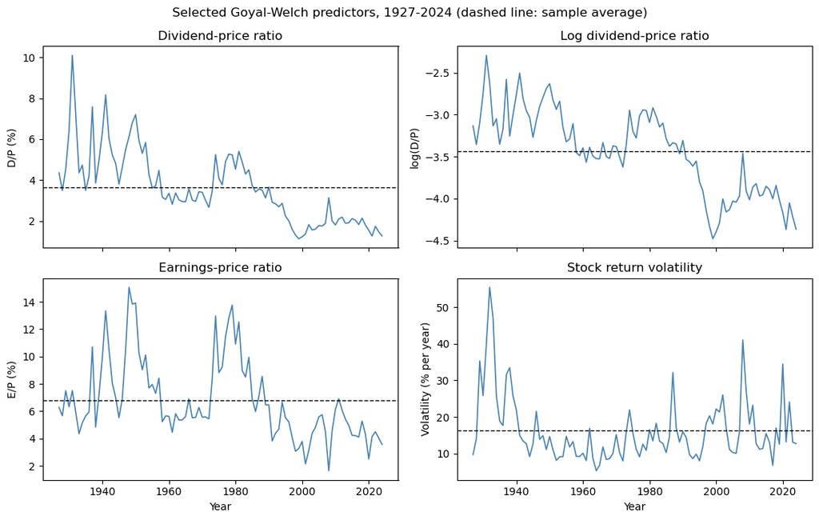

```python
#Four of the predictors: D/P and E/P ratios (in percent), log D/P, and annualized stock volatility
data['svol'] = 100 * np.sqrt(data['svar'])   #annual volatility in percent, from the sum of squared daily returns

panels = [('DPlevel', "Dividend-price ratio", "D/P (%)"),
          ('dp', "Log dividend-price ratio", "log(D/P)"),
          ('EPlevel', "Earnings-price ratio", "E/P (%)"),
          ('svol', "Stock return volatility", "Volatility (% per year)")]

fig, axes = plt.subplots(2, 2, figsize=(11, 7), sharex=True)
for ax, (col, title, ylabel) in zip(axes.flat, panels):
    ax.plot(years, data[col], color='steelblue', linewidth=1.2)
    ax.axhline(data[col].mean(), color='black', linestyle='--', linewidth=1)
    ax.set_title(title)
    ax.set_ylabel(ylabel)
for ax in axes[1]:
    ax.set_xlabel("Year")
fig.suptitle("Selected Goyal-Welch predictors, 1927-2024 (dashed line: sample average)")
fig.tight_layout()
plt.show()
```

## Persistence in the Predictors

The table below reports summary statistics for the returns and each predictor. (Kurtosis is reported in excess of 3, so a normal distribution has a value of 0.) The last column is especially important: it contains the sample first-order autocorrelation, AC(1), for each variable. (If needed, look back at `TimeSeries.ipynb` for autocorrelation and persistence.)

```python
#Summary statistics for the returns and the candidate predictors
predictor_list = ['dp', 'dy', 'ep', 'de', 'bm', 'tbl', 'lty', 'ltr', 'corpr', 'tms', 'dfy', 'dfr', 'infl', 'ntis', 'svar']
summary = data[['lexret', 'exret'] + predictor_list].agg(['mean', 'std', 'min', 'max', 'skew', 'kurt']).T
summary['AC(1)'] = data[['lexret', 'exret'] + predictor_list].apply(lambda s: s.autocorr(lag=1))
summary.round(3)
```

|  | mean | std | min | max | skew | kurt | AC(1) |
| --- | --- | --- | --- | --- | --- | --- | --- |
| lexret | 6.447 | 18.917 | -54.956 | 42.139 | -0.840 | 0.834 | 0.030 |
| exret | 8.655 | 19.664 | -42.689 | 52.603 | -0.323 | -0.120 | -0.000 |
| dp | -3.434 | 0.496 | -4.478 | -2.293 | -0.168 | -0.683 | 0.904 |
| dy | -3.372 | 0.471 | -4.503 | -2.434 | -0.383 | -0.693 | 0.946 |
| ep | -2.777 | 0.419 | -4.106 | -1.893 | -0.140 | 0.473 | 0.756 |
| de | -0.656 | 0.321 | -1.225 | 0.646 | 1.043 | 2.612 | 0.604 |
| bm | 0.536 | 0.269 | 0.131 | 1.442 | 0.676 | 0.277 | 0.870 |
| tbl | 3.369 | 3.058 | 0.010 | 15.490 | 1.129 | 1.757 | 0.890 |
| lty | 4.885 | 2.714 | 0.930 | 13.340 | 1.079 | 0.613 | 0.953 |
| ltr | 5.675 | 9.920 | -14.898 | 40.350 | 0.893 | 1.279 | -0.127 |
| corpr | 6.141 | 8.688 | -15.762 | 42.562 | 0.960 | 2.725 | 0.030 |
| tms | 1.516 | 1.415 | -3.500 | 4.530 | -0.389 | 0.750 | 0.619 |
| dfy | 1.171 | 0.756 | 0.340 | 5.100 | 2.541 | 8.575 | 0.705 |
| dfr | 0.466 | 4.476 | -17.072 | 17.899 | -0.190 | 3.632 | -0.312 |
| infl | 3.057 | 3.933 | -10.274 | 18.132 | 0.320 | 3.969 | 0.619 |
| ntis | 1.536 | 2.686 | -4.064 | 16.352 | 2.067 | 10.219 | 0.640 |
| svar | 0.035 | 0.047 | 0.003 | 0.307 | 3.434 | 14.401 | 0.606 |

The returns themselves have essentially no autocorrelation, but there is wide variation in the degree of persistence across the predictors. Several of them are *very* persistent, especially the valuation ratios `dp`, `dy`, and `bm` and the interest rate levels `tbl` and `lty`, with first-order autocorrelations of roughly 0.85 to 0.95. This turns out to be important.

Below, we look more closely at the log dividend-price ratio: its autocorrelation function (ACF), an AR(1) model, and the **augmented Dickey-Fuller (ADF) test**. The ADF test is a formal test of the null hypothesis that a series has a *unit root* (recall from `TimeSeries.ipynb` that a unit root process, like a random walk, is nonstationary and never reverts to a fixed mean), against the alternative that the series is stationary. A large $p$-value means the data are consistent with a unit root.

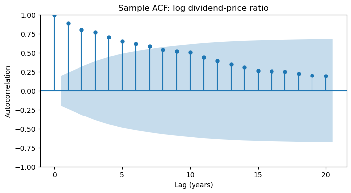

```python
#ACF of the log dividend-price ratio
fig, ax = plt.subplots(figsize=(8, 4))
sm.graphics.tsa.plot_acf(data['dp'], lags=20, ax=ax, title="Sample ACF: log dividend-price ratio")
ax.set_xlabel("Lag (years)")
ax.set_ylabel("Autocorrelation")
plt.show()
```

```python
#AR(1) model for the log dividend-price ratio
ar1_dp = AutoReg(data['dp'], lags=1).fit()
print(ar1_dp.summary())

#ADF unit root test (null: unit root; alternative: stationary)
adf_stat, adf_pvalue = adfuller(data['dp'])[:2]
print(f"\nADF test for a unit root in dp: statistic = {adf_stat:.2f}, p-value = {adf_pvalue:.2f}")
```

```
                            AutoReg Model Results
==============================================================================
Dep. Variable:                     dp   No. Observations:                   98
Model:                     AutoReg(1)   Log Likelihood                  13.142
Method:               Conditional MLE   S.D. of innovations              0.211
Date:                Mon, 05 Oct 2026   AIC                            -20.285
Time:                        17:32:40   BIC                            -12.560
Sample:                    12-31-1928   HQIC                           -17.161
                         - 12-31-2024
==============================================================================
                 coef    std err          z      P>|z|      [0.025      0.975]
------------------------------------------------------------------------------
const         -0.2876      0.152     -1.888      0.059      -0.586       0.011
dp.L1          0.9197      0.044     20.883      0.000       0.833       1.006
                                    Roots
=============================================================================
                  Real          Imaginary           Modulus         Frequency
-----------------------------------------------------------------------------
AR.1            1.0873           +0.0000j            1.0873            0.0000
-----------------------------------------------------------------------------

ADF test for a unit root in dp: statistic = -1.32, p-value = 0.62
```

The autocorrelations of $dp$ die off only slowly, the estimated AR(1) coefficient is about 0.9, and the ADF test is nowhere near rejecting the null of a unit root. So it is not completely clear whether $dp$ is stationary at all. (Economic logic says it should be: if dividends and prices drifted apart forever, D/P would eventually go to zero or infinity. But in a sample of this length, the data cannot tell a highly persistent stationary process apart from a unit root process.) We will come back to why this matters for predictive regressions.

## A First Predictive Regression: Score One for the EMH

The first predictive regression we run just uses the *lagged* excess return as the predictor. (This is just an AR(1) model for returns, from `TimeSeries.ipynb`!)

We use the `statsmodels` OLS functionality to run the regression. Because we will run many predictive regressions, the code first defines a small helper function, `predictive_regression`, that does the one thing that is easy to get wrong: lining up next year's outcome $y_{t+1}$ with this year's predictor(s) $x_t$.

It is *very* important to get the lagging right! If you ever see a huge $R^2$ in a "predictive" regression, double-check that you lagged the predictor appropriately.

```python
def predictive_regression(target, predictors, cov_type='nonrobust'):
    """OLS regression of next period's target (y_{t+1}) on a constant and this period's predictor(s) (x_t).

    target: a Series; predictors: a Series (one predictor) or DataFrame (several).
    The last observation drops out automatically, since its next-period outcome isn't observed yet."""
    y_next = target.shift(-1).rename(f"{target.name}_next")   #row t now holds y_{t+1}
    X = sm.add_constant(predictors)
    df = pd.concat([y_next, X], axis=1).dropna()
    return sm.OLS(df[y_next.name], df[X.columns]).fit(cov_type=cov_type)

#Excess return next year on the excess return this year
reg_lag = predictive_regression(data['exret'], data['exret'])
print(reg_lag.summary())
```

```
                            OLS Regression Results
==============================================================================
Dep. Variable:             exret_next   R-squared:                       0.000
Model:                            OLS   Adj. R-squared:                 -0.011
Method:                 Least Squares   F-statistic:                 1.504e-05
Date:                Mon, 05 Oct 2026   Prob (F-statistic):              0.997
Time:                        17:32:40   Log-Likelihood:                -425.76
No. Observations:                  97   AIC:                             855.5
Df Residuals:                      95   BIC:                             860.7
Df Model:                           1
Covariance Type:            nonrobust
==============================================================================
                 coef    std err          t      P>|t|      [0.025      0.975]
------------------------------------------------------------------------------
const          8.4011      2.182      3.851      0.000       4.070      12.732
exret         -0.0004      0.102     -0.004      0.997      -0.203       0.202
==============================================================================
Omnibus:                        1.666   Durbin-Watson:                   2.013
Prob(Omnibus):                  0.435   Jarque-Bera (JB):                1.613
Skew:                          -0.307   Prob(JB):                        0.446
Kurtosis:                       2.848   Cond. No.                         23.4
==============================================================================

Notes:
[1] Standard Errors assume that the covariance matrix of the errors is correctly specified.
```

What do we find from the regression output?

- The coefficient on the lagged return is essentially zero and statistically insignificant.
- The $R^2$ is essentially zero.

This is fully consistent with the efficient markets hypothesis: last year's return tells us nothing about next year's.

## The Famous Dividend-Price Ratio Regression

Next, we run a different return forecasting regression, in which the predictor is not the lagged excess return but the (lagged) dividend-price ratio:

$$R_{t+1} = \alpha + \beta \, DP_{t} + \epsilon_{t+1}$$

Loose logic: D/P moves around but gradually reverts to its mean. If it is currently high, then prices are "low relative to dividends", so we conjecture that prices should rise in the future. Thus, we conjecture a positive slope coefficient: $\beta > 0$.

We first run this regression on a sample of returns from 1947 through 2009 (so the predictor runs from 1946 through 2008), a period over which this regression became famous. Here $R$ is the simple excess return (`exret`) and $DP$ is the D/P ratio in percent (`DPlevel`).

```python
#1947-2009 sample: returns 1947-2009, predicted by D/P in 1946-2008
cochrane = data.loc['1946':'2009']
reg_dp_cochrane = predictive_regression(cochrane['exret'], cochrane['DPlevel'])
print(reg_dp_cochrane.summary())

#Economic magnitude: implied standard deviation of the expected excess return, beta x SD(D/P)
sd_dp = cochrane['DPlevel'].iloc[:-1].std()   #D/P values actually used as predictors (1946-2008)
beta_dp = reg_dp_cochrane.params['DPlevel']
print(f"\nSD of D/P: {sd_dp:.2f} percentage points")
print(f"Implied SD of the expected excess return: {beta_dp:.2f} x {sd_dp:.2f} = {beta_dp * sd_dp:.1f}% per year")
```

```
                            OLS Regression Results
==============================================================================
Dep. Variable:             exret_next   R-squared:                       0.112
Model:                            OLS   Adj. R-squared:                  0.097
Method:                 Least Squares   F-statistic:                     7.680
Date:                Mon, 05 Oct 2026   Prob (F-statistic):            0.00739
Time:                        17:32:40   Log-Likelihood:                -266.31
No. Observations:                  63   AIC:                             536.6
Df Residuals:                      61   BIC:                             540.9
Df Model:                           1
Covariance Type:            nonrobust
==============================================================================
                 coef    std err          t      P>|t|      [0.025      0.975]
------------------------------------------------------------------------------
const         -7.3189      5.747     -1.273      0.208     -18.812       4.174
DPlevel        4.1881      1.511      2.771      0.007       1.166       7.210
==============================================================================
Omnibus:                        0.819   Durbin-Watson:                   2.016
Prob(Omnibus):                  0.664   Jarque-Bera (JB):                0.908
Skew:                          -0.242   Prob(JB):                        0.635
Kurtosis:                       2.667   Cond. No.                         10.9
==============================================================================

Notes:
[1] Standard Errors assume that the covariance matrix of the errors is correctly specified.

SD of D/P: 1.42 percentage points
Implied SD of the expected excess return: 4.19 x 1.42 = 5.9% per year
```

### Discussion of the D/P regression

It is worth breaking down the regression output in detail.

The $R^{2}$ for the regression is about 11%. That seems small, doesn't it? *But* remember our earlier discussion of market efficiency, and the coin toss example, where a very valuable signal produced an $R^2$ of only 4%. *A really large $R^2$ would be extremely difficult to reconcile with market efficiency.* From the efficient markets perspective, *any* predictability is surprising, and from this perspective an $R^2$ of 11% actually seems large.

Let's look at the magnitude of the slope coefficient on $DP$ for a different perspective. Our estimate is around 4.

We can get a sense of the *economic* significance of the predictive power of the dividend-price ratio by computing the standard deviation of the expected excess return (the market risk premium) implied by the model. Since $E_t(R_{t+1}) = \alpha + \beta \, DP_t$ and $\alpha$ is a constant, this equals:

$$\sigma \left( E_t(R_{t+1}) \right) = \beta \times \sigma(DP) \approx 4 \times 1.4 \approx 5.9\%$$

So the model implies an annual standard deviation of the market risk premium of around 6%.

That's huge! Economically, the result says that instead of the market risk premium being constant over time at some value like 7% per year, it gyrates around so much that its annual standard deviation is around 6%. Apply confidence interval notions: if this variation were normally distributed (not necessarily the case in truth), then in around one-third of years the equity premium would be either below about 1% or above about 13%.

Here's another way to look at it (an argument due to John Cochrane). Suppose D/P rises by one percentage point. How much higher should we expect next year's return to be?

1. "Unsophisticated investor" perspective: the coefficient should be 1.0, because if I am being paid 1% more in dividends, then I should get a 1% higher return.
2. "(Classic) sophisticated investor" perspective: no, the coefficient should be zero. Returns are not forecastable. The price is low today (D/P increased by 1%) because everyone expects dividends to be lower in the future; this is "already priced in", and hence returns remain unforecastable.
3. *Our regression output*: actually, the effect is about *4 times greater* than the unsophisticated investor's view! A higher D/P comes with a higher dividend yield *and* with prices that tend to rise afterwards.

What about *statistical* significance? After all, perhaps we got 4 by random chance. However, the $t$-statistic on the lagged dividend-price ratio is around 2.8. This seems reasonably strong evidence against the null that the true slope coefficient is zero.

### Cautionary note 1: more data

The D/P regression seems convincing. But it turns out that there are issues. First, we have more data. What happens if we re-run the regression over the full 1928-2024 sample of returns, instead of 1947-2009?

```python
#Same regression, full sample: returns 1928-2024, predicted by D/P in 1927-2023
reg_dp_full = predictive_regression(data['exret'], data['DPlevel'])
print(reg_dp_full.summary())
```

```
                            OLS Regression Results
==============================================================================
Dep. Variable:             exret_next   R-squared:                       0.019
Model:                            OLS   Adj. R-squared:                  0.009
Method:                 Least Squares   F-statistic:                     1.853
Date:                Mon, 05 Oct 2026   Prob (F-statistic):              0.177
Time:                        17:32:40   Log-Likelihood:                -424.82
No. Observations:                  97   AIC:                             853.6
Df Residuals:                      95   BIC:                             858.8
Df Model:                           1
Covariance Type:            nonrobust
==============================================================================
                 coef    std err          t      P>|t|      [0.025      0.975]
------------------------------------------------------------------------------
const          2.7405      4.604      0.595      0.553      -6.399      11.880
DPlevel        1.5491      1.138      1.361      0.177      -0.710       3.808
==============================================================================
Omnibus:                        2.982   Durbin-Watson:                   1.952
Prob(Omnibus):                  0.225   Jarque-Bera (JB):                2.875
Skew:                          -0.416   Prob(JB):                        0.238
Kurtosis:                       2.863   Cond. No.                         9.87
==============================================================================

Notes:
[1] Standard Errors assume that the covariance matrix of the errors is correctly specified.
```

The evidence becomes much less impressive. The slope coefficient falls from about 4 to about 1.5, the $R^2$ falls to around 2%, and the $t$-statistic is only around 1.4 -- not significant at conventional levels. So is there really predictability? It is not so clear.

### Cautionary note 2: persistent predictors and biased slopes

There is also a second, subtler problem. Remember that D/P is very *persistent* -- almost a unit root process. This turns out to cause statistical problems for the predictive regression, even when the sample is "clean". The key ingredients are:

- The predictor is highly persistent (AR(1) coefficient close to one).
- The *shock* to the predictor is strongly correlated with the *shock* to returns. For D/P this correlation is strongly negative, and for a mechanical reason: when stock prices jump up unexpectedly, the return is high *and* D/P falls (its denominator, the price, just went up).

Together, these imply that:

- For persistent financial ratios like D/P (or E/P or B/M), the OLS slope estimate in the predictive regression is *biased upward* in small samples.
- Although the bias disappears as the sample size becomes "large", it can be meaningful for the sample sizes available in practice (here, under 100 annual observations).
- The bias makes us *overoptimistic* about the degree of predictability, and makes us reject the null of no predictability more often than we should.

The intuition: it is well known that the OLS estimate of an AR(1) coefficient is biased *downward* in small samples (it tends to underestimate persistence). Because return shocks and D/P shocks are so strongly negatively correlated, any error in estimating D/P's persistence spills over into the return regression, in the opposite direction. Stambaugh (1999) showed that, to a good approximation, the bias in $\hat{\beta}$ is

$$E(\hat{\beta}) - \beta \approx -\frac{\sigma_{uv}}{\sigma_v^2} \times \frac{1 + 3\phi}{T}$$

where $\phi$ is the predictor's AR(1) coefficient, $T$ the sample size, and $\sigma_{uv}/\sigma_v^2$ is the slope from regressing the return shock $u$ on the predictor shock $v$ (negative for D/P, which makes the bias positive). We won't derive this, but we can easily check it by simulation.

The simulation below uses the *log* dividend-price ratio and log excess returns (the version of the regression in which these properties are cleanest), calibrated to our full-sample estimates. It generates many artificial 97-year histories in which **the true slope is exactly zero** -- D/P has no predictive power whatsoever -- and runs the predictive regression on each one. For comparison, it repeats the exercise with the two shocks uncorrelated.

```python
#Calibrate the simulation to the full-sample log D/P regression and the AR(1) model for log D/P
reg_logdp = predictive_regression(data['lexret'], data['dp'])
phi = ar1_dp.params.iloc[1]
#Line up the return shock u_{t+1} (labeled t, the predictor's year) with the D/P shock v_{t+1} (labeled t+1)
shocks = pd.concat([reg_logdp.resid.rename('u'), ar1_dp.resid.shift(-1).rename('v')], axis=1).dropna()
sd_u, sd_v = shocks['u'].std(), shocks['v'].std()
corr_uv = shocks['u'].corr(shocks['v'])
T_sim = int(reg_logdp.nobs)
print(f"Estimated slope on log D/P: {reg_logdp.params['dp']:.2f} (t = {reg_logdp.tvalues['dp']:.2f})")
print(f"Calibration: phi = {phi:.3f}, SD(u) = {sd_u:.2f}, SD(v) = {sd_v:.3f}, corr(u, v) = {corr_uv:.2f}, T = {T_sim}")

def simulate_slopes(corr, n_reps=5000, seed=4414):
    """Simulate n_reps samples with a TRUE slope of zero; return the OLS slope estimates and t-statistics."""
    rng = np.random.default_rng(seed)
    slopes, tstats = np.empty(n_reps), np.empty(n_reps)
    cov = [[sd_u**2, corr * sd_u * sd_v], [corr * sd_u * sd_v, sd_v**2]]
    for i in range(n_reps):
        uv = rng.multivariate_normal([0, 0], cov, size=T_sim)
        x = np.empty(T_sim + 1)
        x[0] = rng.normal(0, sd_v / np.sqrt(1 - phi**2))   #start the predictor from its stationary distribution
        for t in range(T_sim):
            x[t + 1] = phi * x[t] + uv[t, 1]                #persistent predictor
        r_next = uv[:, 0]                                  #returns: pure noise, so the true slope is zero
        fit = sm.OLS(r_next, sm.add_constant(x[:-1])).fit()
        slopes[i], tstats[i] = fit.params[1], fit.tvalues[1]
    return slopes, tstats

slopes_corr, tstats_corr = simulate_slopes(corr_uv)
slopes_zero, tstats_zero = simulate_slopes(0.0)

stambaugh = -(corr_uv * sd_u / sd_v) * (1 + 3 * phi) / T_sim
print(f"\nStambaugh bias approximation: {stambaugh:.2f}")
print(pd.DataFrame({
    'Average slope estimate': [slopes_corr.mean(), slopes_zero.mean()],
    'Rejection rate, 5% test (%)': [100 * np.mean(np.abs(tstats_corr) > 1.96), 100 * np.mean(np.abs(tstats_zero) > 1.96)],
}, index=[f'corr(u, v) = {corr_uv:.2f}', 'corr(u, v) = 0']).round(2))
```

```
Estimated slope on log D/P: 4.51 (t = 1.15)
Calibration: phi = 0.920, SD(u) = 18.69, SD(v) = 0.213, corr(u, v) = -0.85, T = 97
```

```
Stambaugh bias approximation: 2.91
                    Average slope estimate  Rejection rate, 5% test (%)
corr(u, v) = -0.85                    3.23                         8.92
corr(u, v) = 0                       -0.07                         5.20
```

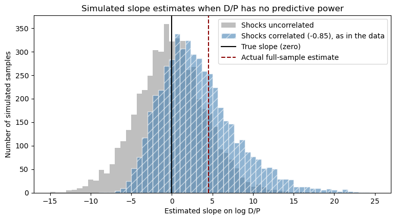

```python
#Distribution of the slope estimates when the true slope is zero
fig, ax = plt.subplots(figsize=(9, 4.5))
bins = np.linspace(-15, 25, 61)
ax.hist(slopes_zero, bins=bins, alpha=0.5, color='gray', label='Shocks uncorrelated')
ax.hist(slopes_corr, bins=bins, alpha=0.6, color='steelblue', hatch='//', edgecolor='white',
        label=f'Shocks correlated ({corr_uv:.2f}), as in the data')
ax.axvline(0, color='black', linewidth=1.5, label='True slope (zero)')
ax.axvline(reg_logdp.params['dp'], color='darkred', linestyle='--', linewidth=1.5,
           label='Actual full-sample estimate')
ax.set_title("Simulated slope estimates when D/P has no predictive power")
ax.set_xlabel("Estimated slope on log D/P")
ax.set_ylabel("Number of simulated samples")
ax.legend()
plt.show()
```

The simulation confirms the problem. When the shocks are uncorrelated, the slope estimates are centered on the true value of zero. But with the strongly negative correlation we see in the data, the estimates are shifted to the right: on average, OLS finds a positive slope of roughly 3 even though the true slope is zero, in line with the Stambaugh approximation. That is a large fraction of our actual full-sample estimate of about 4.5. The bias also pushes the rejection rate of a nominal 5% $t$-test above 5%, so standard $t$-statistics overstate the evidence for predictability somewhat.

**Bottom line**: the dividend-price ratio *might* forecast returns, but it is hard to make an iron-clad statistical case that the true slope coefficient is not zero.

## Many Predictors, One at a Time

D/P is only one candidate. The code below runs a separate univariate predictive regression of the log excess return (`lexret`) on each of the Goyal-Welch predictors, over the full sample and over the 1947-2009 sample. For each regression, the table reports the slope, its $t$-statistic, and the $R^2$. Note that the dividend-price ratio enters here in *logs* (`dp`), so its slope is not directly comparable to the D/P-in-percent regression above. (The units of the predictors differ, so compare $t$-statistics and $R^2$ across rows, not the slopes.)

**Robust standard errors.** The table uses an important option in `statsmodels`' regression code. Standard errors for regression estimates depend on our assumptions about the regression errors. The simplest ("classical") assumption is that the variance of the regression error is a constant that doesn't depend on the levels of the explanatory variables. In practice this assumption is often tenuous, and the errors are likely to be **heteroskedastic**: for example, returns are much more volatile in some economic states than in others. `statsmodels` can compute **heteroskedasticity-robust** standard errors (often called "White" standard errors) that remain valid in that case, by passing the argument `cov_type='HC1'` to `.fit()`. ("HC1" is one of several closely related versions; it includes a small-sample adjustment.) In practice, you should generally use robust standard errors for predictive regressions.

```python
def univariate_table(df, target='lexret'):
    """One predictive regression of target on each predictor in predictor_list, with robust (HC1) standard errors."""
    rows = {}
    for p in predictor_list:
        res = predictive_regression(df[target], df[p], cov_type='HC1')
        rows[p] = {'beta': res.params[p], 't-stat': res.tvalues[p], 'R2 (%)': 100 * res.rsquared}
    return pd.DataFrame(rows).T

univariate = pd.concat({'Returns 1928-2024 (full sample)': univariate_table(data),
                        'Returns 1947-2009': univariate_table(data.loc['1946':'2009'])}, axis=1)
univariate.round(2)
```

|  | Returns 1928-2024 (full sample) beta | Returns 1928-2024 (full sample) t-stat | Returns 1928-2024 (full sample) R2 (%) | Returns 1947-2009 beta | Returns 1947-2009 t-stat | Returns 1947-2009 R2 (%) |
| --- | --- | --- | --- | --- | --- | --- |
| dp | 4.51 | 1.07 | 1.37 | 12.20 | 2.61 | 10.12 |
| dy | 4.96 | 1.21 | 1.50 | 10.36 | 2.18 | 7.76 |
| ep | 5.36 | 1.23 | 1.40 | 8.12 | 1.53 | 4.77 |
| de | 1.44 | 0.20 | 0.06 | 9.82 | 1.71 | 2.38 |
| bm | 11.49 | 1.61 | 2.66 | 11.79 | 1.36 | 3.08 |
| tbl | -0.86 | -1.50 | 1.95 | -1.04 | -1.56 | 3.30 |
| lty | -0.66 | -1.09 | 0.90 | -0.72 | -1.08 | 1.39 |
| ltr | 0.22 | 1.60 | 1.29 | 0.24 | 1.56 | 2.15 |
| corpr | 0.23 | 1.52 | 1.12 | 0.21 | 1.32 | 1.34 |
| tms | 1.61 | 1.32 | 1.45 | 1.70 | 1.18 | 2.15 |
| dfy | 0.80 | 0.27 | 0.10 | 2.88 | 0.91 | 0.80 |
| dfr | -0.20 | -0.47 | 0.22 | -0.48 | -0.75 | 1.24 |
| infl | 0.02 | 0.03 | 0.00 | -0.59 | -1.00 | 1.53 |
| ntis | -1.77 | -1.85 | 6.39 | 0.82 | 0.48 | 0.76 |
| svar | 28.39 | 0.58 | 0.50 | 69.53 | 1.30 | 1.08 |

### Discussion of the univariate results

Over the full sample, the evidence for predictability is weak: *none* of the predictors has a $t$-statistic beyond 2 in absolute value (net issuance, `ntis`, comes closest), and the $R^2$ values are mostly below 3%. Over the 1947-2009 sample, the dividend-based ratios look considerably stronger (the log D/P $t$-statistic is above 2.5, with an $R^2$ of around 10%, and the log dividend yield is also significant), which helps explain why the D/P regression was so influential in the literature written around that time.

The two samples tell noticeably different stories. That sensitivity to the sample period is itself a warning sign: a relationship that comes and goes with the choice of sample is harder to trust than one that holds up throughout. And with 15 candidate predictors, finding one or two $t$-statistics beyond 2 would not be surprising by chance alone, even if none of them truly predicted returns (the same multiple-testing problem we saw when reading ACF plots in `TimeSeries.ipynb`). Here the two that clear the bar, `dp` and `dy`, are nearly the same variable, so they are really one piece of evidence, not two.

## A Multivariate Predictive Regression

So far we have examined the predictors one at a time. But why do this? Why not combine the information from multiple predictors?

Below, we estimate a relatively large (in the sense of number of predictors) "kitchen sink" model. We don't use *all* of the predictors from the table above, because then we would run into serious problems with **multicollinearity** -- when a variable in the regression is an exact or near-exact linear function of other variables in the model. For example, `tms` is exactly `lty` minus `tbl`, and the log valuation ratios satisfy $ep = dp - de$, so including all of them at once would make some coefficients impossible to estimate separately. We again use robust (HC1) standard errors.

```python
#A "kitchen sink" multivariate predictive regression (omitting some predictors to avoid multicollinearity)
ks_predictors = ['dp', 'corpr', 'dfy', 'infl', 'ltr', 'lty', 'ntis', 'svar', 'tms']
reg_ks = predictive_regression(data['lexret'], data[ks_predictors], cov_type='HC1')
print(reg_ks.summary())
```

```
                            OLS Regression Results
==============================================================================
Dep. Variable:            lexret_next   R-squared:                       0.174
Model:                            OLS   Adj. R-squared:                  0.089
Method:                 Least Squares   F-statistic:                     2.560
Date:                Mon, 05 Oct 2026   Prob (F-statistic):             0.0116
Time:                        17:32:50   Log-Likelihood:                -412.86
No. Observations:                  97   AIC:                             845.7
Df Residuals:                      87   BIC:                             871.5
Df Model:                           9
Covariance Type:                  HC1
==============================================================================
                 coef    std err          z      P>|z|      [0.025      0.975]
------------------------------------------------------------------------------
const         62.4530     16.638      3.754      0.000      29.844      95.062
dp            13.2519      4.082      3.246      0.001       5.250      21.253
corpr          0.2399      0.505      0.475      0.634      -0.749       1.229
dfy           -8.9262      4.440     -2.010      0.044     -17.628      -0.224
infl           0.1499      0.515      0.291      0.771      -0.859       1.159
ltr            0.0410      0.409      0.100      0.920      -0.761       0.843
lty           -0.7033      0.648     -1.086      0.278      -1.973       0.566
ntis          -2.6349      0.957     -2.754      0.006      -4.510      -0.760
svar          90.4593     64.182      1.409      0.159     -35.335     216.253
tms            1.2156      1.221      0.995      0.320      -1.178       3.610
==============================================================================
Omnibus:                       12.523   Durbin-Watson:                   2.088
Prob(Omnibus):                  0.002   Jarque-Bera (JB):               14.088
Skew:                          -0.732   Prob(JB):                     0.000873
Kurtosis:                       4.158   Cond. No.                         589.
==============================================================================

Notes:
[1] Standard Errors are heteroscedasticity robust (HC1)
```

### Discussion of results: the overfitting issue

When we include the variables jointly in the predictive regression, the log dividend-price ratio becomes highly significant, with a $t$-statistic above 3. A couple of other predictors are also significant at conventional levels.

Based on several of the individual $t$-statistics, there seems to be strong evidence of predictability from this multivariate model. And look at that $R^{2}$ of around 17%! That looks really good.

*...maybe too good?*

We added a lot of variables to the regression. The mechanics of OLS are such that $R^{2}$ *cannot fall* when we add more variables, and in general it increases. This raises the potential of **overfitting**, which refers to fitting the noise in a particular "training" sample. With a sufficient number of explanatory variables, one can "explain" all of the variation in the left-hand side variable *in a particular sample*. But this does not mean that the model will do a good job explaining a *different sample*.

The **adjusted $R^{2}$** reported in the regression output attempts to account for the number of parameters. With $T$ observations and $K$ predictors (plus a constant), it is

$$\bar{R}^2 = 1 - (1 - R^2) \times \frac{T - 1}{T - K - 1}$$

In words, it scales up the unexplained fraction of the variance, $1 - R^2$, by a factor that grows with the number of predictors $K$ relative to the sample size. Adding a predictor that explains very little therefore *lowers* $\bar{R}^2$. In the earlier univariate regressions, regular and adjusted $R^{2}$ values were very similar ($K = 1$). But for this model, with many predictors and not much data (under 100 observations), there is a big difference.

Still, the adjusted $R^{2}$ is around 9%. If this were indicative of future predictive power, we could run quite a market-timing fund based on our model!

## Out-of-Sample (OOS) Analysis

Rather than relying on corrected fit measures like adjusted $R^{2}$, a common approach is to evaluate a model's performance *out of sample* (OOS). The key feature of an OOS analysis is that the parameters used to produce each forecast must be estimated using only data that would have been available, in real time, to a potential trader. This is not the case for the "in-sample" (or "full-sample") regressions above, which picked the parameters that best fit *all of the data*.

The key message of the Goyal and Welch (2008) paper (available through the VT library link on Canvas) is that, when the performance of return forecasting models is assessed OOS, many of the models struggle to outperform a very simple benchmark: the historical average return.

OOS evaluations usually proceed via the following steps:

1. Pick an initial span of data that will be used to estimate the model parameters. In our case, we will use 30 years: returns from 1928 through 1957, regressed on predictors from 1927 through 1956. We run the predictive regression on this sample and store the estimated parameters.
2. Using the estimated parameters and the current (1957) values of the predictor variables, we compute the first OOS forecast for returns: a forecast for 1958.
3. Then we move forward one year. Now the outcome for 1958 is assumed to be observed. We update the model parameters by re-running the predictive regression including 1958. Sometimes we retain all of the earlier data (an "expanding window"), and sometimes researchers instead use a "rolling" window of fixed length, so that the next sample would drop the oldest year.
4. Using the updated parameters and the values of the predictor variables in 1958, we compute the forecast for 1959.

We continue in this way until we have produced a forecast for the final year of our sample. As a point of comparison, we also compute forecasts using just the (expanding) historical average of past returns. This is the benchmark against which we compare the predictive regression model.

### Mean squared forecast error

Given the OOS forecasts for our model of interest and for the benchmark, we compute the forecast errors (the actual return minus the forecast) for each period in which a forecast was made.

The standard measure of performance is the **mean squared forecast error** (MSFE) over the OOS period. It is defined exactly the way the term suggests:

$$MSFE = \frac{1}{T_{OOS}} \sum_{t=1}^{T_{OOS}} e_{t}^{2}$$

where $T_{OOS}$ is the number of OOS periods and $e_{t}$ is the period-$t$ forecast error. Intuitively, we square the forecast error because, just like in OLS, we want to penalize large misses in either direction.

Let $MSFE$ be the mean squared forecast error for our model and $MSFE_{BMK}$ the MSFE for the benchmark (here, the historical average). It is common to report an OOS analog of the traditional regression $R^{2}$:

$$R^{2}_{OOS} = 1 - \frac{MSFE}{MSFE_{BMK}}$$

In words, $R^2_{OOS}$ is the fraction by which the model reduces the benchmark's mean squared forecast error. A few key properties:

1. If the MSFEs of the model and the benchmark are equal, then $R^{2}_{OOS} = 0$.
2. If our model is perfect ($MSFE = 0$), then $R^{2}_{OOS} = 1$.
3. Unlike the traditional $R^{2}$, $R^{2}_{OOS}$ can be negative (in fact, arbitrarily so). This happens whenever the MSFE of our model exceeds that of the benchmark, i.e., whenever the model underperforms the benchmark.

### Goyal-Welch plots

Goyal and Welch also plot the running performance of a forecasting model against the historical average: the *cumulative* sum, over the OOS period, of the benchmark's squared forecast error minus the model's squared forecast error.

Intuition:

- If in a given period the predictive regression model outperforms the benchmark, then the benchmark's squared error is larger, and the cumulative sum *increases* that period.
- If the plot finishes in positive (negative) territory, then the MSFE of the predictive regression model is lower (higher) than that of the benchmark.
- Periods where the line slopes upward (downward) are periods when the predictive regression (benchmark) is performing better.

### Python OOS analysis of the multivariate model

Below we use Python to analyze the OOS performance of the multivariate "kitchen sink" model, which looked quite good in the full sample.

To illustrate the mechanics, we first compute a single prediction from the full-sample model: a forecast for 2025, based on the 2024 values of the predictors. We cannot (yet) assess the accuracy of this prediction -- the point is just to show how to get a predicted value from an estimated regression. Note that `.predict()` needs the constant included alongside the predictors, and that `sm.add_constant` needs `has_constant='add'` when given a single row (otherwise it doesn't add a constant, because a single row of any variable looks "constant").

```python
#Forecast for 2025 from the full-sample kitchen sink model, using the 2024 predictor values
X_2024 = sm.add_constant(data[ks_predictors].iloc[[-1]], has_constant='add')
print(X_2024.round(3))
forecast_2025 = reg_ks.predict(X_2024).iloc[0]
print(f"\nKitchen sink model forecast of the 2025 log excess return: {forecast_2025:.2f}%")
print(f"Historical average log excess return, 1927-2024:          {data['lexret'].mean():.2f}%")
```

```
      const     dp  corpr  dfy   infl    ltr   lty   ntis   svar   tms
year
2024    1.0 -4.364  2.125  0.6  2.888  0.577  4.39 -0.461  0.016  0.12

Kitchen sink model forecast of the 2025 log excess return: -0.04%
Historical average log excess return, 1927-2024:          6.45%
```

Now the real OOS exercise. The function below loops through the OOS years with an expanding estimation window. For each year $t$ it uses only data through year $t-1$: it re-estimates the predictive regression on the pairs (predictors in year $s$, return in year $s+1$) available by then, plugs in the predictor values from year $t-1$, and records the forecast alongside the historical-average forecast (the mean of all returns through year $t-1$).

```python
def oos_forecasts(df, target, predictors, n_init=30):
    """Expanding-window out-of-sample forecasts of df[target] from a predictive regression and from the
    historical mean. The forecast for year t uses only data through year t-1. The first forecast uses a
    regression estimated on n_init (predictor, next-year return) pairs."""
    rows = []
    for t in range(n_init + 1, len(df)):
        past = df.iloc[:t]                       #all years up to and including year t-1
        res = predictive_regression(past[target], past[predictors])
        x_latest = sm.add_constant(past[predictors].iloc[[-1]], has_constant='add')   #predictors in year t-1
        rows.append({'year': df.index[t],
                     'actual': df[target].iloc[t],
                     'model': res.predict(x_latest).iloc[0],
                     'hist_mean': past[target].mean()})
    return pd.DataFrame(rows).set_index('year')

oos = oos_forecasts(data, 'lexret', ks_predictors)
print(f"OOS period: {oos.index[0]} to {oos.index[-1]} ({len(oos)} years)")
oos.head()
```

```
OOS period: 1958 to 2024 (67 years)
```

| year | actual | model | hist_mean |
| --- | --- | --- | --- |
| 1958 | 33.474953 | 42.160282 | 7.568582 |
| 1959 | 7.954488 | 1.547667 | 8.378157 |
| 1960 | -2.888093 | 37.778227 | 8.365318 |
| 1961 | 21.284119 | 47.321613 | 8.034335 |
| 1962 | -11.946075 | 15.026996 | 8.412901 |

```python
#Forecast errors and squared errors, in decimals (as in Goyal and Welch's plots)
oos['err_model'] = (oos['actual'] - oos['model']) / 100
oos['err_hmean'] = (oos['actual'] - oos['hist_mean']) / 100
msfe_model = (oos['err_model']**2).mean()
msfe_hmean = (oos['err_hmean']**2).mean()
r2_oos = 1 - msfe_model / msfe_hmean

print(f"MSFE, historical average:      {msfe_hmean:.4f}")
print(f"MSFE, predictive regression:   {msfe_model:.4f}")
print(f"Out-of-sample R-squared:       {100 * r2_oos:.1f}%")

#Cumulative sum of squared-error differences, for the Goyal-Welch plot
oos['csum_sq_err_diff'] = (oos['err_hmean']**2 - oos['err_model']**2).cumsum()
```

```
MSFE, historical average:      0.0268
MSFE, predictive regression:   0.0440
Out-of-sample R-squared:       -64.0%
```

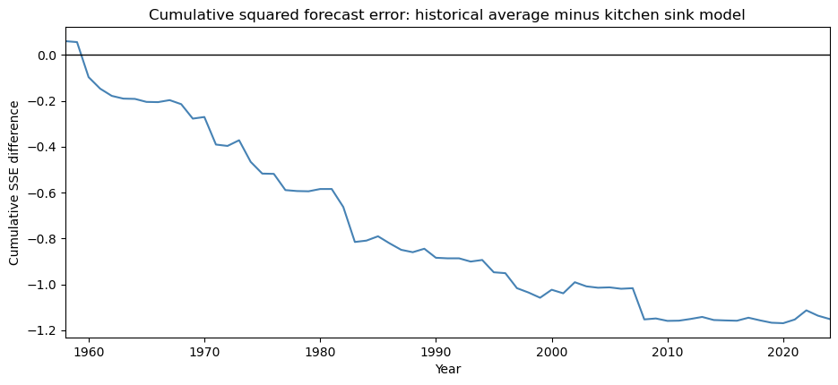

```python
#Goyal-Welch plot: cumulative (benchmark squared error - model squared error)
fig, ax = plt.subplots(figsize=(11, 4.5))
ax.plot(oos.index.year, oos['csum_sq_err_diff'], color='steelblue', linewidth=1.5)
ax.axhline(0, color='black', linewidth=1)
ax.set_title("Cumulative squared forecast error: historical average minus kitchen sink model")
ax.set_xlabel("Year")
ax.set_ylabel("Cumulative SSE difference")
ax.set_xlim(oos.index.year.min(), oos.index.year.max())
plt.show()
```

### OOS results discussion

Bluntly, the OOS analysis indicates that our "kitchen sink" predictive regression model performs very poorly out of sample, and much worse than the simple historical average.

The $R^{2}_{OOS}$ statistic is strongly negative, and the Goyal-Welch plot of the cumulative sum of squared error differences shows the model falling behind the historical average early in the OOS period and continuing to lose ground for decades. Only since around 2010 has it roughly broken even with the benchmark, and it never recovers the ground lost earlier.

To see why it does so poorly, the next plot compares the predictions from the historical average with those of the predictive regression model.

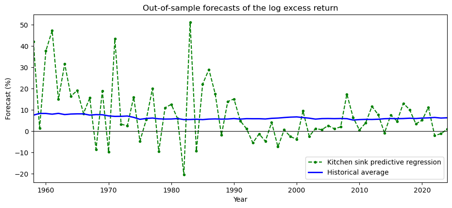

```python
#Compare the two sets of OOS forecasts
fig, ax = plt.subplots(figsize=(11, 4.5))
ax.plot(oos.index.year, oos['model'], color='green', linestyle='--', marker='o', markersize=3,
        label='Kitchen sink predictive regression')
ax.plot(oos.index.year, oos['hist_mean'], color='blue', linewidth=2, label='Historical average')
ax.axhline(0, color='black', linewidth=0.8)
ax.set_title("Out-of-sample forecasts of the log excess return")
ax.set_xlabel("Year")
ax.set_ylabel("Forecast (%)")
ax.set_xlim(oos.index.year.min(), oos.index.year.max())
ax.legend(loc='lower right')
plt.show()
```

The predictions from the multivariate regression model gyrate wildly, from large positive forecasts to large negative ones. This behavior is especially pronounced early in the OOS period. Remember that the first regression is estimated with only 30 observations, but there are 10 parameters (9 slopes and an intercept), so the estimates are *very* noisy. The overfitting problem leads the model to produce wild, unstable forecasts. In contrast, the historical average forecast is nice and smooth. Later in the sample, as the estimation window grows, the model's forecasts settle down to some extent, but they still swing far more than the historical average.

## Takeaways

- A predictive regression is an ordinary OLS regression in which the predictor is observed *before* the outcome. Its fitted line is a model of the conditional expected return, and "predictable returns" means the expected return moves with observable information, not that future returns are known.
- Because realized returns are so noisy, even a genuinely valuable signal produces a small $R^2$ (4% in the coin toss example). In return forecasting, small $R^2$ values can be economically important.
- Market efficiency says returns should be hard to predict; limits to arbitrage and time-varying risk premiums are two reasons some predictability might survive. The present-value relation says valuation ratios like D/P must forecast future returns, future dividend growth, or both.
- In-sample, the D/P regression looks impressive on the 1947-2009 sample (a slope around 4, implying an expected market excess return that varies with a standard deviation of around 6% per year), but the evidence weakens substantially over the full 1928-2024 sample.
- D/P is extremely persistent, and its shocks are strongly negatively correlated with return shocks. Together these bias the OLS slope upward and make $t$-tests over-reject; our simulation found a bias of roughly 3 in the log D/P slope when the true slope is zero.
- A "kitchen sink" multivariate regression fits well in-sample, even after adjusting $R^2$ for the number of predictors, but out of sample it does far worse than the simple historical average. This is the central message of Goyal and Welch (2008).

**Where this goes next.** There has been a lot of research following Goyal and Welch. Two of the most common directions are:

1. Look at different predictors. An upcoming homework assignment is based on one of these, the "variance risk premium". Some of these newer predictors seem to do better than the original Goyal-Welch set, even out of sample.
2. Use better statistical methods to deal with the overfitting problem. Many approaches have been tried (principal components or "factors" extracted from many predictors, the Lasso, combining forecasts from many individual models). The general idea is to stabilize the forecasts -- so they don't look like the dashed green line above -- while still exploiting the information in many potential predictors.

## Additional Technical Material

This appendix collects technical details that were stated without proof, or skipped, in the main text above.

### Deriving the log-linear present-value relation

Start from the definition of the (gross) return on a stock from $t$ to $t+1$, with $P$ the price and $D$ the dividend:

$$R_{t+1} = \frac{P_{t+1} + D_{t+1}}{P_t}$$

Write lower-case letters for logs: $r_{t+1} = \log R_{t+1}$, $p_t = \log P_t$, $d_t = \log D_t$, and $dp_t = d_t - p_t$. Factoring $P_{t+1}$ out of the numerator,

$$r_{t+1} = \log\left(\frac{P_{t+1}}{P_t} \left(1 + \frac{D_{t+1}}{P_{t+1}}\right)\right) = (p_{t+1} - p_t) + \log\left(1 + e^{dp_{t+1}}\right)$$

The last term is a nonlinear function of $dp_{t+1}$. Approximate it with a first-order Taylor expansion around the average value $\overline{dp}$:

$$\log\left(1 + e^{dp_{t+1}}\right) \approx k + (1 - \rho)\, dp_{t+1}, \qquad \text{where } 1 - \rho = \frac{e^{\overline{dp}}}{1 + e^{\overline{dp}}}, \text{ i.e., } \rho = \frac{1}{1 + e^{\overline{dp}}}$$

and $k$ is a constant. (The slope $1-\rho$ is just the derivative of $\log(1 + e^{x})$, evaluated at $x = \overline{dp}$.) Since $e^{\overline{dp}}$ is the typical D/P ratio -- a few percent per year -- $\rho$ is a little less than one. In our data, the average log D/P is about $-3.4$, so $\rho = 1/(1 + e^{-3.4}) \approx 0.97$.

Next, rewrite the price change in terms of $dp$ and dividend growth $\Delta d_{t+1} = d_{t+1} - d_t$. Since $p = d - dp$,

$$p_{t+1} - p_t = (d_{t+1} - dp_{t+1}) - (d_t - dp_t) = \Delta d_{t+1} - dp_{t+1} + dp_t$$

Substituting both pieces into the expression for $r_{t+1}$:

$$r_{t+1} \approx k + \Delta d_{t+1} - dp_{t+1} + dp_t + (1 - \rho)\, dp_{t+1} = k + dp_t + \Delta d_{t+1} - \rho\, dp_{t+1}$$

Solve for $dp_t$:

$$dp_t \approx -k + (r_{t+1} - \Delta d_{t+1}) + \rho\, dp_{t+1}$$

This says today's D/P equals next period's return minus dividend growth, plus a discounted version of *next period's* D/P. Now apply the same equation to $dp_{t+1}$, substitute it in, and keep going:

$$dp_t \approx -k(1 + \rho) + (r_{t+1} - \Delta d_{t+1}) + \rho (r_{t+2} - \Delta d_{t+2}) + \rho^2 dp_{t+2} \approx \cdots \approx -\frac{k}{1 - \rho} + \sum_{j=1}^{\infty} \rho^{j-1} (r_{t+j} - \Delta d_{t+j})$$

where we assume $\rho^{J} dp_{t+J} \to 0$ as $J \to \infty$ (no "bubble" in which D/P explodes). Finally, this holds (approximately) along every possible path of future returns and dividends, so it also holds in expectation. Taking $E_t(\cdot)$ of both sides, and noting $dp_t$ is known at $t$, gives the relation in the main text:

$$dp_t \approx \text{constant} + E_t\left[\sum_{j=1}^{\infty} \rho^{j-1} (r_{t+j} - \Delta d_{t+j})\right]$$

### The multivariate predictive regression in vector notation

**Warning: this subsection uses matrix and vector notation, which the course has not covered in depth. It is safe to skip.**

With $K$ predictors, collect them into a $K \times 1$ vector $x_t = (x_{1,t}, \ldots, x_{K,t})'$ and the slopes into $\beta = (\beta_1, \ldots, \beta_K)'$. The multivariate predictive regression can then be written compactly as

$$y_{t+1} = \alpha + \beta' x_t + \epsilon_{t+1}$$

where $\beta' x_t = \beta_1 x_{1,t} + \cdots + \beta_K x_{K,t}$ is the inner product of the two vectors. Stacking the $T$ observations, with $\mathbf{X}$ the $T \times (K+1)$ matrix whose row for period $t$ is $(1, x_t')$ and $\mathbf{y}$ the $T \times 1$ vector of outcomes $y_{t+1}$, the OLS estimates are $(\hat\alpha, \hat\beta')' = (\mathbf{X}'\mathbf{X})^{-1}\mathbf{X}'\mathbf{y}$. Multicollinearity is the case where one column of $\mathbf{X}$ is (nearly) a linear combination of the others, so that $\mathbf{X}'\mathbf{X}$ is (nearly) singular and cannot be reliably inverted. The OOS forecast for period $t+1$ is $\hat\alpha_t + \hat\beta_t' x_t$, where the subscript $t$ on the estimates indicates that they were computed from data available through period $t$.